# Explanation analysis of bike- sharing system covering the area of San Francisco Bay in the month of February 2019.

## How many Customers and Subscribers are the members of the bike riding system.

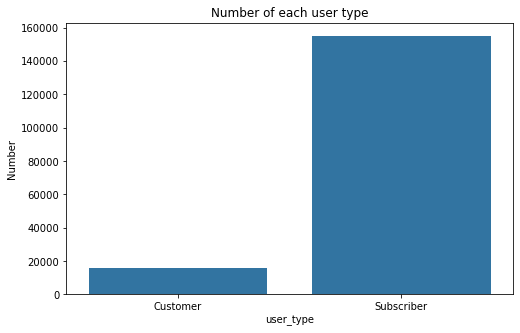

## Which gender has higher number of riders in the bike riding system.

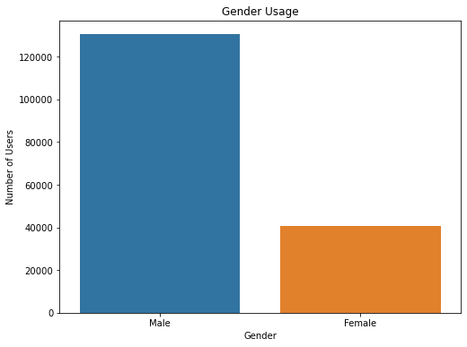

## Male has higher number compare to Female, number of Male is more than 120,000 while female is around 40,000.That is Male number is triple the Female number, so many factors might associated with , male gender maybe dominant in the area,also due to nature of male, male loves sport especially when it associates with physical strenght which female does not like to do.

## Which of the gender shared the ride with other when riding the bike.

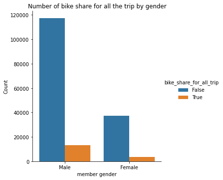

## The visual shows that Male gender share more bikes than their Female counterpart, the count bike share Male almost triple the Female one. Also the number of Male that does not shared the bike during the riding is far more than Female ones.

## Which of the user type has higher duration during riding of the bikes

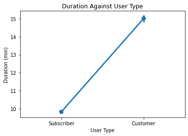

## Customer clients ride duration is higher than that of Subcriber clients, while Subcriber clients are below ten minutes the Customer clients mark at fifteen minutes. This depicts that Customer clients rides bikes more than Subcriber clients.

### Which day with station id has member gender highest number?

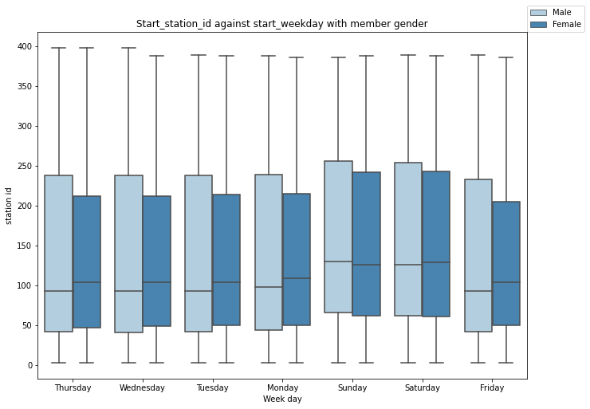

## Sunday and Saturday have highest number of male and female with start station id while other day are almost the same in number of start station id,except friday which is least in term of male and female in the start station.

### What day does member gender has the higher trip during the week day.

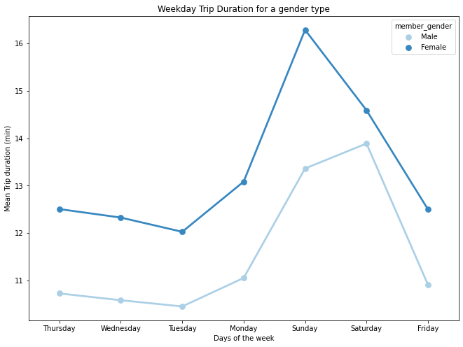

## The female riders has their peak on Sunday followed by Saturday and Monday and their lowest on Tuesday, while Male riders has their peak of ride on Saturday followed by Sunday and lowest on Tuesday, but averagely Female has higher Trip duration than the Male on every day.